# Scrolls, Sleep and State of Mind

Jade Go

## Introduction

I’d been noticing that I was spending a lot of time on my phone and feeling increasingly tired. I wanted to know if my digital habits were connected to these. So over the course of a week, I invited a few university friends to join me in this study. Together, we tracked our daily screen time, how many times we unlocked our phones, how long we slept, and how we felt each day. What follows is what the data revealed.

## Screen Time is highest mid-week and on Sundays

The mid-week spike is perhaps unsurprising. Busier days tend to bring more phone activity, whether it’s checking messages, staying on top of work, or unwinding with entertainment. The weekend, however, tells a more mixed story. Sunday is high but Saturday is notably low, suggesting that for at least some of us, Saturdays are spent more off-screen, maybe spent outside with friends or family rather than on our screens.

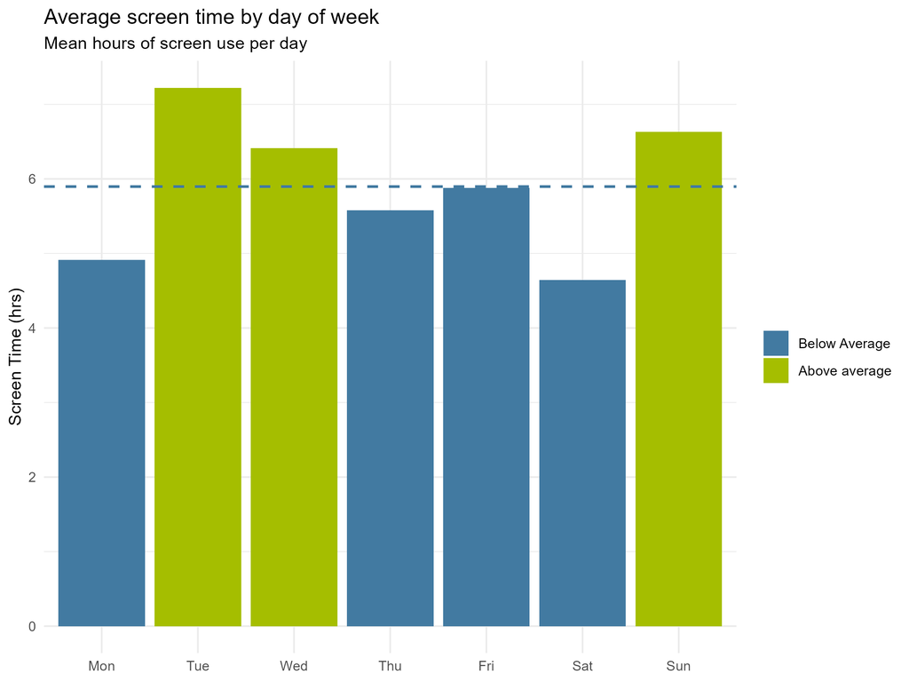

Bar chart showing average screen time for each day of the week

## Sleep looks very different depending on mood

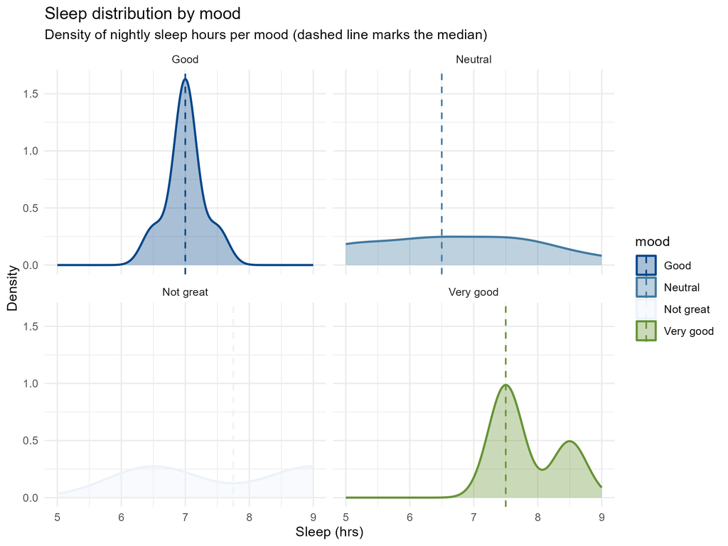

Faceted density plots showing the distribution of sleep hours for each mood levels

## On bad days, we check our phone almost twice as often

This is the most striking finding in the data. On days we rate “Not great”, the average number of phone unlocks was 193.5, nearly double the roughly 97-98 unlocks recorded on both “Good” and “Neutral” days. “Very good” days had the fewest unlocks at just 53.3. This suggests a strong link between mood and compulsive phone checking. When feeling low, reaching for the phone becomes automatic. Whether the phone use drives the mood or the mood drives the phone use is harder to say, but the gap is hard to ignore.

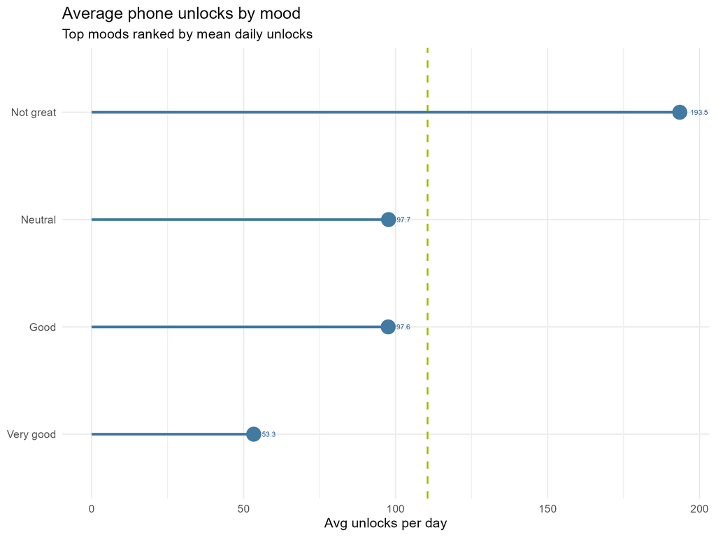

Lollipop chart ranking the moods by average daily phone unlocks

## Conclusion

Taken together, these three visualisations tell a consistent story: mood and phone behaviour are closely intertwined. Screen time peak mid-week and on Sundays. Sleep is most consistent and centred around 7 hours on good days, but inconsistent on neutral ones. And most strikingly, low mood days are associated with almost double the phone checks compared to good or neutral days.

While this data reflects just a small group of university students over a limited period, the patterns are consistent enough to pay attention to.